# N741 Spring 2018 - Homework 6

Homework 6

Rosemary Kinuthia

April 2, 2018

```r
helpdata <- haven::read_spss("helpmkh.sav")
```

```r
sub1 <- helpdata %>%
  select(age, female, pss_fr, homeless,
         pcs, mcs, cesd)
```

```r
# create a function to get the label
# label output from the attributes() function
getlabel <- function(x) attributes(x)$label
# getlabel(sub1$age)
```

```r
# load libraries and dataset
library(tidyverse)
library(haven)
helpdata <- haven::read_spss("helpmkh.sav")
```

```r
# choose variables for Homework 6
h1 <- helpdata %>%
  select(age, female, pss_fr, homeless,
         pcs, mcs, cesd)
```

```r
# add dichotomous variable
# to indicate depression for
# people with CESD scores >= 16

h1 <- h1 %>%
  mutate(cesd_gte16 = cesd >= 16)
```

```r
# change cesd_gte16 LOGIC variable type
# to numeric coded 1=TRUE and 0=FALSE

h1$cesd_gte16 <- as.numeric(h1$cesd_gte16)
```

```r
# check final data subset h1
summary(h1)
```

```
##       age            female           pss_fr          homeless
##  Min.   :19.00   Min.   :0.0000   Min.   : 0.000   Min.   :0.0000
##  1st Qu.:30.00   1st Qu.:0.0000   1st Qu.: 3.000   1st Qu.:0.0000
##  Median :35.00   Median :0.0000   Median : 7.000   Median :0.0000
##  Mean   :35.65   Mean   :0.2362   Mean   : 6.706   Mean   :0.4614
##  3rd Qu.:40.00   3rd Qu.:0.0000   3rd Qu.:10.000   3rd Qu.:1.0000
##  Max.   :60.00   Max.   :1.0000   Max.   :14.000   Max.   :1.0000
##       pcs             mcs              cesd         cesd_gte16
##  Min.   :14.07   Min.   : 6.763   Min.   : 1.00   Min.   :0.0000
##  1st Qu.:40.38   1st Qu.:21.676   1st Qu.:25.00   1st Qu.:1.0000
##  Median :48.88   Median :28.602   Median :34.00   Median :1.0000
##  Mean   :48.05   Mean   :31.677   Mean   :32.85   Mean   :0.8985
##  3rd Qu.:56.95   3rd Qu.:40.941   3rd Qu.:41.00   3rd Qu.:1.0000
##  Max.   :74.81   Max.   :62.175   Max.   :60.00   Max.   :1.0000
```

## Homework 6 Tasks

1. [Model 1] Run a simple linear regression (`lm()`) for `cesd` using the `mcs` variable, which is the mental component quality of life score from the SF36.

```r
#linear regression of CESD using MCS
Model1 <- lm(cesd~mcs, data=h1)
summary(Model1)
```

```
##
## Call:
## lm(formula = cesd ~ mcs, data = h1)
##
## Residuals:
##      Min       1Q   Median       3Q      Max
## -27.3593  -6.7277  -0.0024   6.2374  24.4239
##
## Coefficients:
##             Estimate Std. Error t value Pr(>|t|)
## (Intercept) 53.90219    1.14723   46.98   <2e-16 ***
## mcs         -0.66467    0.03357  -19.80   <2e-16 ***
## ---
## Signif. codes:  0 '***' 0.001 '**' 0.01 '*' 0.05 '.' 0.1 ' ' 1
##
## Residual standard error: 9.164 on 451 degrees of freedom
## Multiple R-squared:  0.465,  Adjusted R-squared:  0.4638
## F-statistic:   392 on 1 and 451 DF,  p-value: < 2.2e-16
```

2. Write the equation of the final fitted model (i.e. what is the intercept and the slope)? Write a sentence describing the model results (interpret the intercept and slope). *NOTE: The `mcs` values range form 0 to 100 where the population norm for “normal mental health quality of life” is considered to be a 50. If you score higher than 50 on the `mcs` you have mental health better than the population and visa versa - if your `mcs` scores are less than 50 then your mental health is considered to be worse than the population norm.*

```r
#Y= 53.90-0.66*mcs
#Interpretation: for each unit increase in mcs, cesd decreases by 0.66
```

3. How much variability in the `cesd` does the `mcs` explain? (what is the R<sup>2</sup>?) Write a sentence describing how well the `mcs` does in predicting the `cesd`.

```r
#R-squared=0.465 indicating that the predictor(mcs) explains 46.5% variability in the outcome(cesd)
```

4. [Model 2] Run a second linear regression model (`lm()`) for the `cesd` putting in all of the other variables:
   - `age`
   - `female`
   - `pss_fr`
   - `homeless`
   - `pcs`
   - `mcs`
   - Print out the model results with the coefficients and tests and model fit statistics.

```r
#linear regression for cesd and all other variables
Model2 <- lm(cesd~age + female + pss_fr + homeless + pcs + mcs, data=h1)
summary(Model2)
```

```
##
## Call:
## lm(formula = cesd ~ age + female + pss_fr + homeless + pcs +
##     mcs, data = h1)
##
## Residuals:
##      Min       1Q   Median       3Q      Max
## -25.1711  -5.9894  -0.2077   5.5706  27.3137
##
## Coefficients:
##             Estimate Std. Error t value Pr(>|t|)
## (Intercept) 65.30046    3.18670  20.492  < 2e-16 ***
## age         -0.01348    0.05501  -0.245   0.8065
## female       2.35028    0.98810   2.379   0.0178 *
## pss_fr      -0.25569    0.10567  -2.420   0.0159 *
## homeless     0.46545    0.84261   0.552   0.5810
## pcs         -0.23639    0.03987  -5.929  6.1e-09 ***
## mcs         -0.62093    0.03261 -19.042  < 2e-16 ***
## ---
## Signif. codes:  0 '***' 0.001 '**' 0.01 '*' 0.05 '.' 0.1 ' ' 1
##
## Residual standard error: 8.683 on 446 degrees of freedom
## Multiple R-squared:  0.5249, Adjusted R-squared:  0.5185
## F-statistic: 82.14 on 6 and 446 DF,  p-value: < 2.2e-16
```

5. Which variables are significant in the model? Write a sentence or two describing the impact of these variables for predicting depression scores (HINT: interpret the coefficient terms).

```r
#Female, pss_fr, pcs and mcs are significant

#R-squared is 0.5249 indicating that 52.49% of the variabilty in average cesd is due to the independent variables in the model

#From this output we can see that:
#Being female increases the cesd by 2.35, holding all other variables constant
#If pss_fr increases by one unit, the cesd decreases by 0.26 units, holding all other variables constant.
#If pcs increases by one unit, then the cesd decreases by 0.24 units, holding all other variables constant.
##If mcs increases by one unit, then the cesd decreases by 0.62 units, holding all other variables constant.
```

6. Following the example we did in class for the Prestige dataset https://cdn.rawgit.com/vhertzb/2018week9/2f2ea142/2018week9.html?raw=true, generate the diagnostic plotss for this model with these 6 predictors (e.g. get the residual plot by variables, the added-variable plots, the Q-Q plot, diagnostic plots). Also run the VIFs to check for multicollinearity issues.

```r
library(car)
```

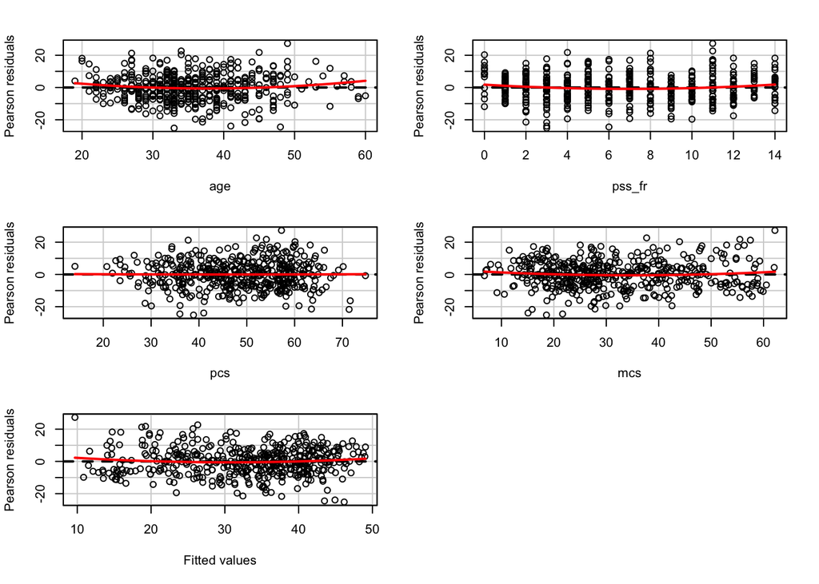

```
##            Test stat Pr(>|t|)
## age            1.941    0.053
## pss_fr         1.964    0.050
## pcs            0.081    0.936
## mcs            1.260    0.208
## Tukey test     1.434    0.152
```

```r
#residual plot
residualPlots(Model2)
```

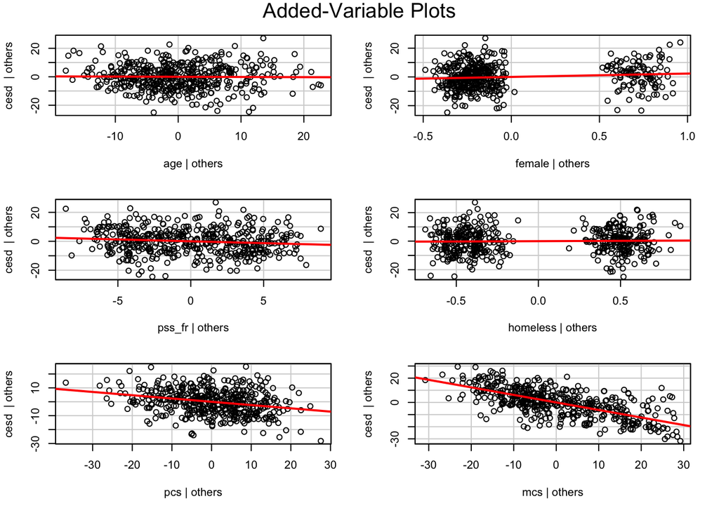

```r
#added variable plots
avPlots(Model2)
```

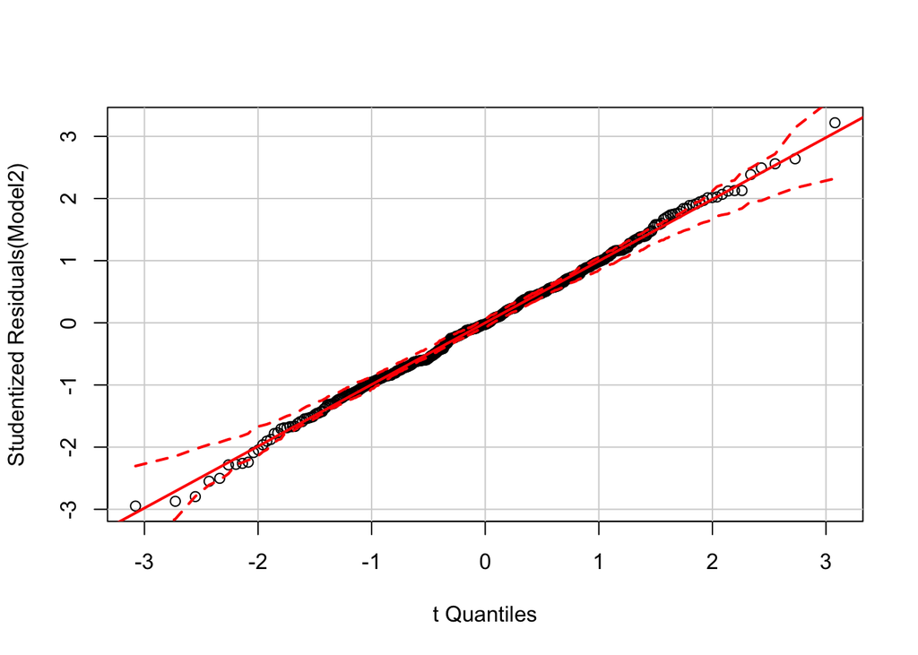

```r
#qq plot
qqPlot(Model2)
```

```r
#run Bonferroni test for outliers
outlierTest(Model2)
```

```
##
## No Studentized residuals with Bonferonni p < 0.05
## Largest |rstudent|:
##     rstudent unadjusted p-value Bonferonni p
## 450 3.218868          0.0013811      0.62564
```

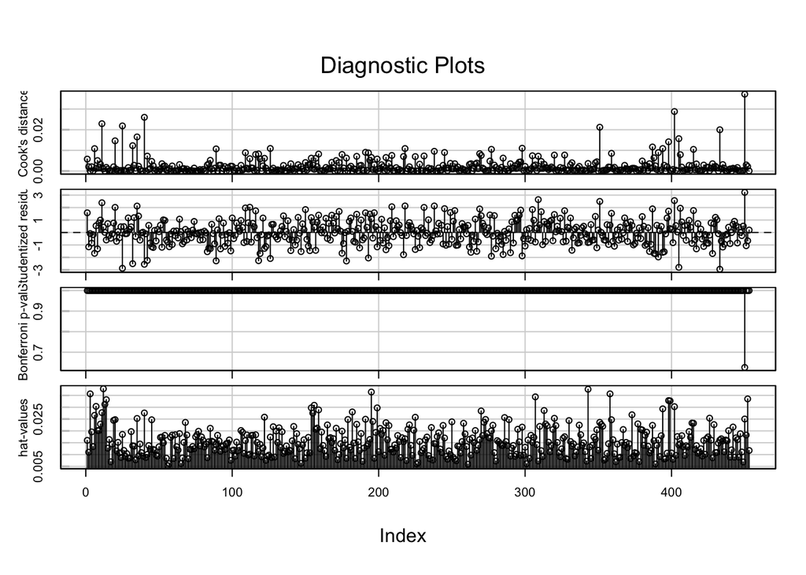

```r
#identify highly influential points
influenceIndexPlot(Model2)
```

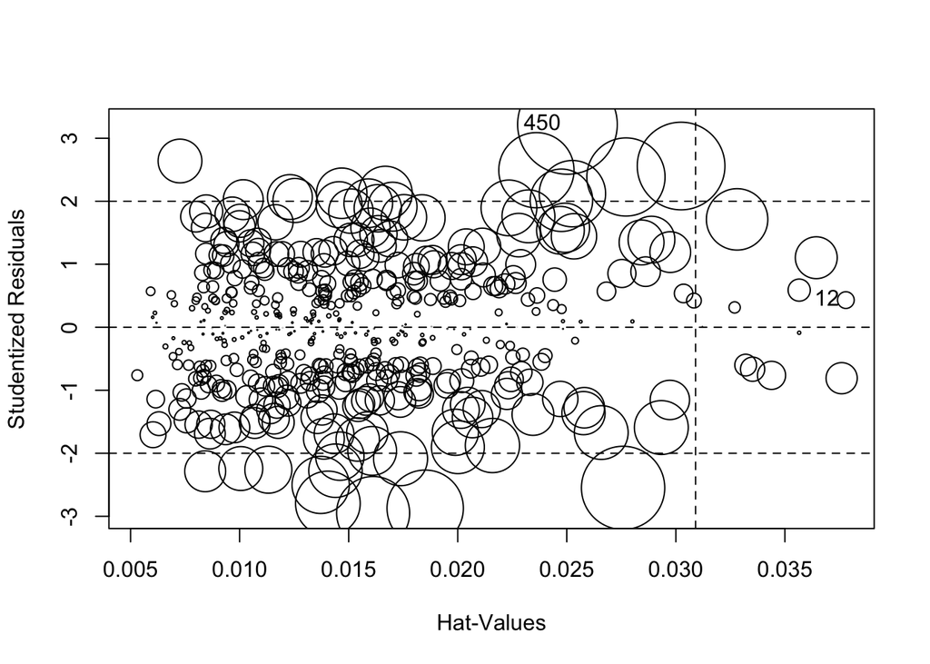

```
##       StudRes        Hat       CookD
## 12  0.4313265 0.03779399 0.001045833
## 450 3.2188680 0.02502996 0.037218269
```

```r
#Influence plot
influencePlot(Model2)
```

7. [Model 3] Repeat Model 1 above, except this time run a logistic regression (`glm()`) to predict CESD scores => 16 (using the `cesd_gte16` as the outcome) as a function of `mcs` scores. Show a summary of the sfinal fitted model and explain the coefficients. [**REMEMBER** to compute the Odds Ratios after you get the raw coefficient (betas)].

```r
#logistic regression using cesd_gte16 as outcome
Model3 <- glm(cesd_gte16~mcs, data=h1, family=binomial)
```